# List Columns

Risa Dickerman

2026-11-05

```r
library(tidyverse)
library(rvest)
library(p8105.datasets)
```

## Attaching package: ‘rvest’

## The following object is masked from ‘package:readr’:

## guess_encoding

```r
set.seed(1)
```

## Lists…

Prove that lists can have anything

```r
l = list(
  vec_numeric = 5:17,
  mat = matrix(1:8, nrow = 2, ncol = 4, byrow = TRUE),
  vec_logical = c(TRUE, FALSE, FALSE),
  summary_table = summary(rnorm(1000)))

l
```

```
## $vec_numeric
##  [1]  5  6  7  8  9 10 11 12 13 14 15 16 17
##
## $mat
##      [,1] [,2] [,3] [,4]
## [1,]    1    2    3    4
## [2,]    5    6    7    8
##
## $vec_logical
## [1]  TRUE FALSE FALSE
##
## $summary_table
##     Min.  1st Qu.   Median     Mean  3rd Qu.     Max.
## -3.00805 -0.69737 -0.03532 -0.01165  0.68843  3.81028
```

```r
l[[1]]
```

```
##  [1]  5  6  7  8  9 10 11 12 13 14 15 16 17
```

```r
#$ is a shorthand for double brackets
l[[2]]
```

```
##      [,1] [,2] [,3] [,4]
## [1,]    1    2    3    4
## [2,]    5    6    7    8
```

```r
l[["vec_logical"]]
```

```
## [1]  TRUE FALSE FALSE
```

## ‘for’ loops

```r
list_norm = list(
  a = rnorm(20, 3, 4),
  b = rnorm(20, -14, 20),
  c = rnorm(30, 1000, 1000),
  d = rnorm(20, 0, 1))
list_norm
```

```
## $a
##  [1]  7.5398604  7.4477274 -0.4831105  3.8429263  3.2775826 -3.6505954
##  [7]  6.2433599 -4.6493832 -1.9870137  6.9926178  0.8365090  2.1344968
## [13] -3.4877492 -2.8038559  4.4036389  2.3018123  0.6342861 -2.3361090
## [19] -1.3891940 11.1444144
##
## $b
##  [1] -20.529792   1.480104   1.700128   1.264922  -8.103825 -39.047118
##  [7] -34.190075   1.027824 -40.167070  -3.449198 -24.670791 -21.967520
## [13] -29.791389 -18.602823   3.543697  -4.925336 -18.649283   3.400110
## [19]  19.120075 -14.127379
##
## $c
##  [1]  1470.48945  1278.21865    22.09706    73.41386  2919.77046  1881.27779
##  [7]  1742.08177  1147.57340  1485.38856  1151.85604  1041.99875  1223.42231
## [13]   -10.46509  3401.22210  1801.96179   748.79204  2212.88937   372.74191
## [19]  2711.15851   605.62645 -1321.49086  2364.11920  2132.22913   225.68368
## [25]  -410.37497  -834.52758   730.98646  -833.92858   185.53198  1163.57212
##
## $d
##  [1]  0.85551922 -0.81996313 -0.12360276  0.25494824  1.71892634 -0.95854353
##  [7] -1.60431026 -1.84560942  0.55573719 -0.06011919  0.77208630 -0.14083939
## [13]  0.39309393  0.22421857  0.02354199 -0.62296266  1.26200938 -0.40577404
## [19]  0.66676377  0.16463915
```

Can I get mean and sd for each sample

```r
source("source_mean_sd.R")
```

```r
mean_and_sd(list_norm[[1]])
```

```
## # A tibble: 1 × 2
##    mean    sd
##   <dbl> <dbl>
## 1  1.80  4.48
```

```r
mean_and_sd(list_norm[[2]])
```

```
## # A tibble: 1 × 2
##    mean    sd
##   <dbl> <dbl>
## 1 -12.3  16.3
```

```r
mean_and_sd(list_norm[[3]])
```

```
## # A tibble: 1 × 2
##    mean    sd
##   <dbl> <dbl>
## 1 1023. 1152.
```

```r
mean_and_sd(list_norm[[4]])
```

```
## # A tibble: 1 × 2
##     mean    sd
##    <dbl> <dbl>
## 1 0.0155 0.891
```

Can I do this better? For loop:

```r
output = vector("list", length = 4)
for(i in 1:4) {
  output[[i]] = mean_and_sd(list_norm[[i]])
}
output
```

```
## [[1]]
## # A tibble: 1 × 2
##    mean    sd
##   <dbl> <dbl>
## 1  1.80  4.48
##
## [[2]]
## # A tibble: 1 × 2
##    mean    sd
##   <dbl> <dbl>
## 1 -12.3  16.3
##
## [[3]]
## # A tibble: 1 × 2
##    mean    sd
##   <dbl> <dbl>
## 1 1023. 1152.
##
## [[4]]
## # A tibble: 1 × 2
##     mean    sd
##    <dbl> <dbl>
## 1 0.0155 0.891
```

## ‘map’ instead

1. Take for loop and modify to make logic a little more clear
2. eventually take statements and build them into tidyverse operations

This is bettter:

```r
output = map(list_norm, mean_and_sd)

output_2 = map(list_norm, IQR)

output
```

```
## $a
## # A tibble: 1 × 2
##    mean    sd
##   <dbl> <dbl>
## 1  1.80  4.48
##
## $b
## # A tibble: 1 × 2
##    mean    sd
##   <dbl> <dbl>
## 1 -12.3  16.3
##
## $c
## # A tibble: 1 × 2
##    mean    sd
##   <dbl> <dbl>
## 1 1023. 1152.
##
## $d
## # A tibble: 1 × 2
##     mean    sd
##    <dbl> <dbl>
## 1 0.0155 0.891
```

```r
output_2
```

```
## $a
## [1] 6.937857
##
## $b
## [1] 23.96206
##
## $c
## [1] 1591.422
##
## $d
## [1] 1.043565
```

output - place we’re going to save it list_norm = list input mean_and_sd = function to apply to list

# What about map variants

```r
output_3 = map_df(list_norm, mean_and_sd)
output_4 = map_dbl(list_norm, median)

output_3
```

```
## # A tibble: 4 × 2
##        mean       sd
##       <dbl>    <dbl>
## 1    1.80      4.48
## 2  -12.3      16.3
## 3 1023.     1152.
## 4    0.0155    0.891
```

```r
output_4
```

```
##             a             b             c             d
##    1.48550293  -11.11560169 1149.71472180    0.09409057
```

way to simplify output

map_dbl = just collapsing everything to a simple output structure -regular map always gives you a list -this just gives you a vector

## List columns

Time to make list columns

```r
listcol_df =
  tibble(
    name = c("a", "b", "c", "d"),
    samp = list_norm
  )
listcol_df
```

```
## # A tibble: 4 × 2
##   name  samp
##   <chr> <named list>
## 1 a     <dbl [20]>
## 2 b     <dbl [20]>
## 3 c     <dbl [30]>
## 4 d     <dbl [20]>
```

named list column: collection of 20 numbers for samp 1

Do stuff with this

```r
listcol_df |>
  filter(name %in% c("a", "b", "c"))
```

```
## # A tibble: 3 × 2
##   name  samp
##   <chr> <named list>
## 1 a     <dbl [20]>
## 2 b     <dbl [20]>
## 3 c     <dbl [30]>
```

```r
listcol_df |>
  pull(samp)
```

```
## $a
##  [1]  7.5398604  7.4477274 -0.4831105  3.8429263  3.2775826 -3.6505954
##  [7]  6.2433599 -4.6493832 -1.9870137  6.9926178  0.8365090  2.1344968
## [13] -3.4877492 -2.8038559  4.4036389  2.3018123  0.6342861 -2.3361090
## [19] -1.3891940 11.1444144
##
## $b
##  [1] -20.529792   1.480104   1.700128   1.264922  -8.103825 -39.047118
##  [7] -34.190075   1.027824 -40.167070  -3.449198 -24.670791 -21.967520
## [13] -29.791389 -18.602823   3.543697  -4.925336 -18.649283   3.400110
## [19]  19.120075 -14.127379
##
## $c
##  [1]  1470.48945  1278.21865    22.09706    73.41386  2919.77046  1881.27779
##  [7]  1742.08177  1147.57340  1485.38856  1151.85604  1041.99875  1223.42231
## [13]   -10.46509  3401.22210  1801.96179   748.79204  2212.88937   372.74191
## [19]  2711.15851   605.62645 -1321.49086  2364.11920  2132.22913   225.68368
## [25]  -410.37497  -834.52758   730.98646  -833.92858   185.53198  1163.57212
##
## $d
##  [1]  0.85551922 -0.81996313 -0.12360276  0.25494824  1.71892634 -0.95854353
##  [7] -1.60431026 -1.84560942  0.55573719 -0.06011919  0.77208630 -0.14083939
## [13]  0.39309393  0.22421857  0.02354199 -0.62296266  1.26200938 -0.40577404
## [19]  0.66676377  0.16463915
```

What about mean and sd

```r
mean_and_sd(pull(listcol_df, samp)[[1]])
```

```
## # A tibble: 1 × 2
##    mean    sd
##   <dbl> <dbl>
## 1  1.80  4.48
```

Can I iterate?

```r
map_df(
  pull(listcol_df, samp), mean_and_sd
  )
```

```
## # A tibble: 4 × 2
##        mean       sd
##       <dbl>    <dbl>
## 1    1.80      4.48
## 2  -12.3      16.3
## 3 1023.     1152.
## 4    0.0155    0.891
```

This is where it gets really cool Apply sd to each of these thinss and save the results:

```r
listcol_df |>
  mutate(
    output = map(samp, mean_and_sd)
  )
```

```
## # A tibble: 4 × 3
##   name  samp         output
##   <chr> <named list> <named list>
## 1 a     <dbl [20]>   <tibble [1 × 2]>
## 2 b     <dbl [20]>   <tibble [1 × 2]>
## 3 c     <dbl [30]>   <tibble [1 × 2]>
## 4 d     <dbl [20]>   <tibble [1 × 2]>
```

```r
listcol_df |>
  mutate(
    output = map_df(samp, mean_and_sd)
  )
```

```
## # A tibble: 4 × 3
##   name  samp         output$mean      $sd
##   <chr> <named list>       <dbl>    <dbl>
## 1 a     <dbl [20]>        1.80      4.48
## 2 b     <dbl [20]>      -12.3      16.3
## 3 c     <dbl [30]>     1023.     1152.
## 4 d     <dbl [20]>        0.0155    0.891
```

```r
listcol_df |>
  mutate(
    output = map(samp, mean_and_sd),
    medians = map_dbl(samp, median)
  )
```

```
## # A tibble: 4 × 4
##   name  samp         output             medians
##   <chr> <named list> <named list>         <dbl>
## 1 a     <dbl [20]>   <tibble [1 × 2]>    1.49
## 2 b     <dbl [20]>   <tibble [1 × 2]>  -11.1
## 3 c     <dbl [30]>   <tibble [1 × 2]> 1150.
## 4 d     <dbl [20]>   <tibble [1 × 2]>    0.0941
```

## Weather data

NSDUH import etc

```r
source("nsduh_process.R")
```

```r
nsduh_url = "https://www.samhsa.gov/data/sites/default/files/NSDUHsaeShortTermCHG2015/NSDUHsaeShortTermCHG2015.htm"

nsduh_html = read_html(nsduh_url)

nsduh_process(html = nsduh_html, table_num = 1)
```

```
## # A tibble: 510 × 4
##    State   age   year      percent
##    <chr>   <chr> <chr>       <dbl>
##  1 Alabama 12+   2013-2014    9.98
##  2 Alabama 12+   2014-2015    9.6
##  3 Alabama 12-17 2013-2014    9.9
##  4 Alabama 12-17 2014-2015    9.71
##  5 Alabama 18-25 2013-2014   27.0
##  6 Alabama 18-25 2014-2015   26.1
##  7 Alabama 26+   2013-2014    7.1
##  8 Alabama 26+   2014-2015    6.81
##  9 Alabama 18+   2013-2014    9.99
## 10 Alabama 18+   2014-2015    9.59
## # ℹ 500 more rows
```

```r
nsduh_process(html = nsduh_html, table_num = 4)
```

```
## # A tibble: 510 × 4
##    State   age   year      percent
##    <chr>   <chr> <chr>       <dbl>
##  1 Alabama 12+   2013-2014    1.23
##  2 Alabama 12+   2014-2015    1.22
##  3 Alabama 12-17 2013-2014    0.42
##  4 Alabama 12-17 2014-2015    0.41
##  5 Alabama 18-25 2013-2014    3.09
##  6 Alabama 18-25 2014-2015    3.2
##  7 Alabama 26+   2013-2014    1.01
##  8 Alabama 26+   2014-2015    0.99
##  9 Alabama 18+   2013-2014    1.31
## 10 Alabama 18+   2014-2015    1.31
## # ℹ 500 more rows
```

```r
nsduh_process(html = nsduh_html, table_num = 5)
```

```
## # A tibble: 510 × 4
##    State   age   year      percent
##    <chr>   <chr> <chr>       <dbl>
##  1 Alabama 12+   2013-2014    0.22
##  2 Alabama 12+   2014-2015    0.27
##  3 Alabama 12-17 2013-2014    0.1
##  4 Alabama 12-17 2014-2015    0.08
##  5 Alabama 18-25 2013-2014    0.45
##  6 Alabama 18-25 2014-2015    0.64
##  7 Alabama 26+   2013-2014    0.19
##  8 Alabama 26+   2014-2015    0.23
##  9 Alabama 18+   2013-2014    0.23
## 10 Alabama 18+   2014-2015    0.29
## # ℹ 500 more rows
```

import using iteration

```r
output = vector("list", length = 3)

table_num = c(1,4,5)

for (i in 1:3) {
  output [[i]] = nsduh_process(html = nsduh_html, table_num = table_num[i])
}
```

let’s build up a map example

```r
map(table_num, nsduh_process, html = nsduh_html)
```

```
## [[1]]
## # A tibble: 510 × 4
##    State   age   year      percent
##    <chr>   <chr> <chr>       <dbl>
##  1 Alabama 12+   2013-2014    9.98
##  2 Alabama 12+   2014-2015    9.6
##  3 Alabama 12-17 2013-2014    9.9
##  4 Alabama 12-17 2014-2015    9.71
##  5 Alabama 18-25 2013-2014   27.0
##  6 Alabama 18-25 2014-2015   26.1
##  7 Alabama 26+   2013-2014    7.1
##  8 Alabama 26+   2014-2015    6.81
##  9 Alabama 18+   2013-2014    9.99
## 10 Alabama 18+   2014-2015    9.59
## # ℹ 500 more rows
##
## [[2]]
## # A tibble: 510 × 4
##    State   age   year      percent
##    <chr>   <chr> <chr>       <dbl>
##  1 Alabama 12+   2013-2014    1.23
##  2 Alabama 12+   2014-2015    1.22
##  3 Alabama 12-17 2013-2014    0.42
##  4 Alabama 12-17 2014-2015    0.41
##  5 Alabama 18-25 2013-2014    3.09
##  6 Alabama 18-25 2014-2015    3.2
##  7 Alabama 26+   2013-2014    1.01
##  8 Alabama 26+   2014-2015    0.99
##  9 Alabama 18+   2013-2014    1.31
## 10 Alabama 18+   2014-2015    1.31
## # ℹ 500 more rows
##
## [[3]]
## # A tibble: 510 × 4
##    State   age   year      percent
##    <chr>   <chr> <chr>       <dbl>
##  1 Alabama 12+   2013-2014    0.22
##  2 Alabama 12+   2014-2015    0.27
##  3 Alabama 12-17 2013-2014    0.1
##  4 Alabama 12-17 2014-2015    0.08
##  5 Alabama 18-25 2013-2014    0.45
##  6 Alabama 18-25 2014-2015    0.64
##  7 Alabama 26+   2013-2014    0.19
##  8 Alabama 26+   2014-2015    0.23
##  9 Alabama 18+   2013-2014    0.23
## 10 Alabama 18+   2014-2015    0.29
## # ℹ 500 more rows
```

Lets try list columns

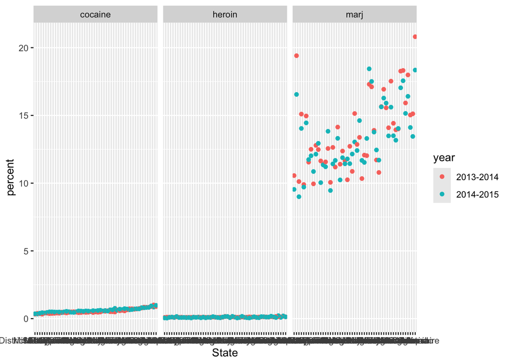

```r
nsduh_df =
  tibble(
    drug = c("marj", "cocaine", "heroin"),
    num = c(1, 4, 5)
  ) |>
  mutate(
    table = map(num, nsduh_process, html = nsduh_html)
  ) |>
  select(-num) |>
  unnest(table)

nsduh_df |>
  filter(age == "12-17", ) |>
  mutate(State = fct_reorder(State, percent)) |>
  ggplot(aes(x = State, y = percent, color = year)) +
  geom_point() +
  facet_grid(. ~ drug)
```

```r
nsduh_df
```

```
## # A tibble: 1,530 × 5
##    drug  State   age   year      percent
##    <chr> <chr>   <chr> <chr>       <dbl>
##  1 marj  Alabama 12+   2013-2014    9.98
##  2 marj  Alabama 12+   2014-2015    9.6
##  3 marj  Alabama 12-17 2013-2014    9.9
##  4 marj  Alabama 12-17 2014-2015    9.71
##  5 marj  Alabama 18-25 2013-2014   27.0
##  6 marj  Alabama 18-25 2014-2015   26.1
##  7 marj  Alabama 26+   2013-2014    7.1
##  8 marj  Alabama 26+   2014-2015    6.81
##  9 marj  Alabama 18+   2013-2014    9.99
## 10 marj  Alabama 18+   2014-2015    9.59
## # ℹ 1,520 more rows
```

before unnest have data frame: 3 rows: drug and full table imported, etc unnest - can unnest and expand those

## Weather again

```r
data("weather_df")

weather_df =
  weather_df |>
  nest(data = date:tmin)
```

Why would you want to do that: suppose you want regress: tmax vs tmin: way to do that:

```r
lm(tmax ~ tmin, data = pull(weather_df, data)[[1]])
```

```
##
## Call:
## lm(formula = tmax ~ tmin, data = pull(weather_df, data)[[1]])
##
## Coefficients:
## (Intercept)         tmin
##       7.514        1.034
```

```r
lm(tmax ~ tmin, data = pull(weather_df, data)[[2]])
```

```
##
## Call:
## lm(formula = tmax ~ tmin, data = pull(weather_df, data)[[2]])
##
## Coefficients:
## (Intercept)         tmin
##     21.7547       0.3222
```

```r
lm(tmax ~ tmin, data = pull(weather_df, data)[[3]])
```

```
##
## Call:
## lm(formula = tmax ~ tmin, data = pull(weather_df, data)[[3]])
##
## Coefficients:
## (Intercept)         tmin
##       7.532        1.137
```

```r
weather_lm = function(input_data) {

  lm(tmax ~ tmin, data = input_data)

}

output = vector("list", 3)
for (i in 1:3) {
output[[i]] = weather_lm(weather_df$data[[i]])
}

weather_lm(pull(weather_df, data)[[1]])
```

```
##
## Call:
## lm(formula = tmax ~ tmin, data = input_data)
##
## Coefficients:
## (Intercept)         tmin
##       7.514        1.034
```

```r
weather_df |>
  mutate(lm_fits = map(data, weather_lm)
         )
```

```
## # A tibble: 3 × 4
##   name           id          data               lm_fits
##   <chr>          <chr>       <list>             <list>
## 1 CentralPark_NY USW00094728 <tibble [730 × 4]> <lm>
## 2 Molokai_HI     USW00022534 <tibble [730 × 4]> <lm>
## 3 Waterhole_WA   USS0023B17S <tibble [730 × 4]> <lm>
```

linear regression model that pulls tmax vs tmin for model dataset: function takes entire dataset and gives data set that fits the model

Applying that function to this dataset and apply to each of the datasets

If want to fit linear model to each column of weather dataframe. Going to mutate to use function to each col of data frame. Add column right next to it to compare side by side

Function simplifies this output: just using lm is complicated but just having one input will simplify and result in a function

If you want to keep track of data with each center, need to use this function.